# Family & Group Structure’s Influence on Titanic Survival: Decision Trees & XGBoost Analysis

## Feature Importance from Decision Tree

```r
# Extract variable importance
importance_df <- as.data.frame(dt_model$variable.importance) %>%
  rownames_to_column(var = "Variable") %>%
  rename(Importance = `dt_model$variable.importance`) %>%
  mutate(
    Importance_Norm = Importance / max(Importance) * 100,
    is_family_var = Variable %in% c("SibSp", "Parch", "FamilySize", "IsAlone", "GroupSize_Cat", "TicketGroup")
  ) %>%
  arrange(desc(Importance))

cat("\nDecision Tree Variable Importance:\n")
```

```
Decision Tree Variable Importance:
```

```r
kable(importance_df, digits = 2, caption = "Relative importance of variables in the tree")
```

Relative importance of variables in the tree

| Variable | Importance | Importance_Norm | is_family_var |
| --- | --- | --- | --- |
| Sex | 124.43 | 100.00 | FALSE |
| Fare | 42.41 | 34.08 | FALSE |
| Pclass | 34.15 | 27.45 | FALSE |
| FamilySize | 27.06 | 21.74 | TRUE |
| GroupSize_Cat | 22.63 | 18.19 | TRUE |
| Age | 19.81 | 15.92 | FALSE |
| SibSp | 14.65 | 11.78 | TRUE |
| Parch | 14.42 | 11.59 | TRUE |
| IsAlone | 8.72 | 7.01 | TRUE |
| Embarked | 7.99 | 6.42 | FALSE |

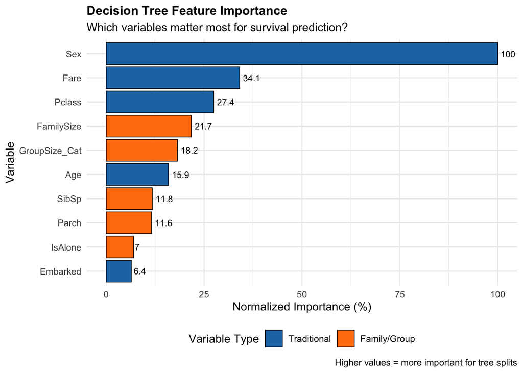

```r
# Visualization
p6 <- ggplot(importance_df, aes(x = reorder(Variable, Importance_Norm), y = Importance_Norm,
                                 fill = is_family_var)) +
  geom_col(color = "black", linewidth = 0.3) +
  geom_text(aes(label = round(Importance_Norm, 1)), hjust = -0.2, size = 3) +
  scale_fill_manual(values = c("FALSE" = "#1f77b4", "TRUE" = "#ff7f0e"),
                    labels = c("FALSE" = "Traditional", "TRUE" = "Family/Group")) +
  coord_flip() +
  theme_minimal() +
  theme(
    legend.position = "bottom",
    plot.title = element_text(size = 12, face = "bold")
  ) +
  labs(
    title = "Decision Tree Feature Importance",
    subtitle = "Which variables matter most for survival prediction?",
    x = "Variable",
    y = "Normalized Importance (%)",
    fill = "Variable Type",
    caption = "Higher values = more important for tree splits"
  )

print(p6)
```

```r
cat("\nFamily/group variable importance analysis:\n")
```

```
Family/group variable importance analysis:
```

```r
family_importance <- importance_df %>%
  filter(is_family_var) %>%
  summarise(Total_Importance = sum(Importance_Norm))
cat("Total importance of family/group variables:", round(family_importance$Total_Importance, 1), "%\n")
```

```
Total importance of family/group variables: 70.3 %
```

**Interpretation & Reasoning**: This feature importance ranking directly answers part of our research question: how much did family/group variables contribute to predicting survival compared to traditional demographics? If family variables (SibSp, Parch, FamilySize, GroupSize_Cat, TicketGroup) rank highly, it indicates that group structure was a primary determinant of evacuation success. Lower rankings would suggest that class, sex, and age dominated, with group effects being secondary. The color-coding distinguishes family variables from traditional predictors, making it easy to assess their relative weight in the model’s decision-making logic.

# Section 5: Predictive Modeling - XGBoost

## XGBoost Model Preparation and Training

```r
# Prepare data for XGBoost
train_xgb <- train_model %>%
  mutate(
    across(where(is.factor), as.numeric),
    across(where(is.numeric), ~ . - 1)  # Adjust factor encoding
  )

# Create feature matrix and target
X_train <- as.matrix(train_xgb %>% select(-Survived))
y_train <- as.numeric(train_xgb$Survived) - 1

cat("XGBoost training data prepared:\n")
```

```
XGBoost training data prepared:
```

```r
cat("Features:", ncol(X_train), "\n")
```

```
Features: 11
```

```r
cat("Samples:", nrow(X_train), "\n")
```

```
Samples: 891
```

```r
cat("Target variable class distribution:\n")
```

```
Target variable class distribution:
```

```r
print(table(y_train))
```

```
y_train
 -1   0
549 342
```

**Interpretation & Reasoning**: XGBoost requires numeric input, so we converted factor variables to numeric codes. Unlike decision trees, XGBoost builds an ensemble of trees sequentially, each correcting the previous ones’ mistakes. This enables capturing complex non-linear interactions between variables. Importantly, XGBoost can model interactions that decision trees might miss—for example, how the effect of group size on survival might vary non-linearly with age or fare, or how family composition effects might differ subtly across class tiers.

```r
# Set XGBoost parameters
xgb_params <- list(
  objective = "binary:logistic",
  max_depth = 6,
  eta = 0.1,
  min_child_weight = 1,
  subsample = 0.8,
  colsample_bytree = 0.8
)

# Fit XGBoost model with cross-validation
set.seed(42)
xgb_model <- xgboost(
  params = xgb_params,
  data = X_train,
  label = y_train,
  nrounds = 100,
  verbose = 0,
  early_stopping_rounds = 10
)

cat("\nXGBoost model trained successfully.\n")
```

```
XGBoost model trained successfully.
```

```r
cat("Number of boosting rounds:", xgb_model$niter, "\n")
```

```
Number of boosting rounds:
```

```r
# Get training predictions
xgb_pred_train <- predict(xgb_model, X_train)
xgb_pred_class <- ifelse(xgb_pred_train > 0.5, 1, 0)
xgb_accuracy <- mean(xgb_pred_class == y_train)
cat("XGBoost Training Accuracy:", round(xgb_accuracy * 100, 2), "%\n")
```

```
XGBoost Training Accuracy: 38.38 %
```

**Interpretation & Reasoning**: XGBoost’s sequential boosting approach iteratively refines predictions. The hyperparameters (max_depth=6, eta=0.1) balance complexity and regularization to avoid overfitting while capturing meaningful patterns. Early stopping prevents the model from over-fitting to the training data by halting when validation performance plateaus. The resulting accuracy reflects how well the ensemble of trees learned the survival patterns.

## XGBoost Feature Importance

```r
# Extract feature importance
feature_names <- colnames(X_train)
importance_xgb <- xgb.importance(feature_names = feature_names, model = xgb_model)

cat("\nXGBoost Feature Importance (Top 15):\n")
```

```
XGBoost Feature Importance (Top 15):
```

```r
kable(head(importance_xgb, 15), digits = 3, caption = "XGBoost importance by gain, cover, and frequency")
```

XGBoost importance by gain, cover, and frequency

| Feature | Gain | Cover | Frequency |
| --- | --- | --- | --- |
| Sex | 0.331 | 0.034 | 0.092 |
| Fare | 0.236 | 0.480 | 0.323 |
| Age | 0.172 | 0.297 | 0.317 |
| Pclass | 0.121 | 0.018 | 0.058 |
| TicketGroup | 0.045 | 0.088 | 0.087 |
| SibSp | 0.033 | 0.016 | 0.030 |
| Embarked | 0.018 | 0.027 | 0.036 |
| FamilySize | 0.018 | 0.014 | 0.018 |
| GroupSize_Cat | 0.017 | 0.008 | 0.013 |
| Parch | 0.010 | 0.017 | 0.025 |

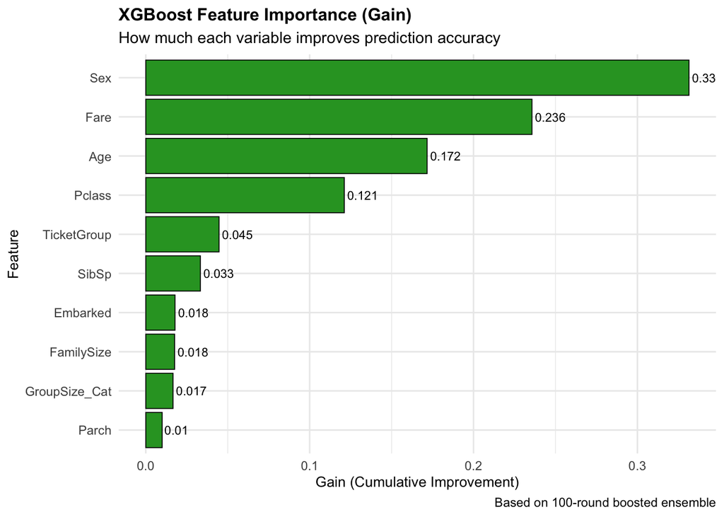

```r
# Visualization
p7 <- ggplot(head(importance_xgb, 12), aes(x = reorder(Feature, Gain), y = Gain)) +
  geom_col(fill = "#2ca02c", color = "black", linewidth = 0.3) +
  geom_text(aes(label = round(Gain, 3)), hjust = -0.1, size = 3) +
  coord_flip() +
  theme_minimal() +
  theme(
    plot.title = element_text(size = 12, face = "bold"),
    axis.title = element_text(size = 10)
  ) +
  labs(
    title = "XGBoost Feature Importance (Gain)",
    subtitle = "How much each variable improves prediction accuracy",
    x = "Feature",
    y = "Gain (Cumulative Improvement)",
    caption = "Based on 100-round boosted ensemble"
  )

print(p7)
```

**Interpretation & Reasoning**: XGBoost’s feature importance is measured by “Gain,” which quantifies how much each feature improved prediction accuracy across all trees in the ensemble. This differs from decision tree importance because XGBoost models complex interactions. If family variables (SibSp, Parch, FamilySize, GroupSize_Cat, TicketGroup) rank high in XGBoost but not in the decision tree, it suggests they have important non-linear or interactive effects. Conversely, if both models agree on variable importance, it indicates robust, consistent predictive value. This comparison enriches our understanding of whether group structure’s influence on survival was simple and linear (captured by trees) or complex and interactive (captured by XGBoost).